# Price Prediction from Toyota Corolla

### Price Prediction from Toyota Corolla

Consider only the below columns and prepare a prediction model for predicting Price. 1. Prediction Model 2. Do proper exploratory Data Analysis and Feature Selection. 3. Upload the Code in the github 4. Share the HTML jupyter notebook in the mail. 5. Use notion.io for process tracking and timeline. Dataset Desription - Model -- model of the car Price -- Offer Price in EUROs Age_08_04 -- Age in months as in August 2004 Mfg_Month -- Manufacturing month (1-12) Mfg_Year -- Manufacturing Year KM -- Accumulated Kilometers on odometer Fuel_Type -- Fuel Type (Petrol, Diesel, CNG) HP -- Horse Power Met_Color -- Metallic Color? (Yes=1, No=0) Color -- Color (Blue, Red, Grey, Silver, Black, etc.) Automatic -- Automatic ( (Yes=1, No=0) cc -- Cylinder Volume in cubic centimeters Doors -- Number of doors Cylinders -- Number of cylinders Gears -- Number of gear positions Quarterly_Tax -- Quarterly road tax in EUROs Weight -- Weight in Kilograms Mfr_Guarantee -- Within Manufacturer's Guarantee period (Yes=1, No=0) BOVAG_Guarantee -- BOVAG (Dutch dealer network) Guarantee (Yes=1, No=0) Guarantee_Period -- Guarantee period in months ABS -- Anti-Lock Brake System (Yes=1, No=0) Airbag_1 -- Driver_Airbag (Yes=1, No=0) Airbag_2 -- Passenger Airbag (Yes=1, No=0) Airco -- Airconditioning (Yes=1, No=0) Automatic_airco -- Automatic Airconditioning (Yes=1, No=0) Boardcomputer -- Boardcomputer (Yes=1, No=0) CD_Player -- CD Player (Yes=1, No=0) Central_Lock -- Central Lock (Yes=1, No=0) Powered_Windows -- Powered Windows (Yes=1, No=0) Power_Steering -- Power Steering (Yes=1, No=0) Radio -- Radio (Yes=1, No=0) Mistlamps -- Mistlamps (Yes=1, No=0) Sport_Model -- Sport Model (Yes=1, No=0) Backseat_Divider -- Backseat Divider (Yes=1, No=0) Metallic_Rim --Metallic Rim (Yes=1, No=0) Radio_cassette -- Radio Cassette (Yes=1, No=0) Tow_Bar -- Tow Bar (Yes=1, No=0)

```python
### Import packages
import pandas as pd
import seaborn as sns
import matplotlib.pyplot as plt
import numpy as np
import math as m
from sklearn.model_selection import train_test_split
from sklearn.linear_model import LinearRegression
from sklearn.preprocessing import LabelEncoder
from sklearn.metrics import r2_score,mean_squared_error
```

```python
#### Reading data from csv file
data = pd.read_csv("H:/COLLEGE WORKS/DATA SCIENCE/Top Mentors/Materials/Python/Simple Linear Regression  - Assignments (2)/Multi Linear Regression/ToyotaCorolla.csv",encoding='unicode_escape')
```

```python
### Check what all values in data
data.head()
```

|  | Id | Model | Price | Age_08_04 | Mfg_Month | Mfg_Year | KM | Fuel_Type | HP | Met_Color | ... | Central_Lock | Powered_Windows | Power_Steering | Radio | Mistlamps | Sport_Model | Backseat_Divider | Metallic_Rim | Radio_cassette | Tow_Bar |
| --- | --- | --- | --- | --- | --- | --- | --- | --- | --- | --- | --- | --- | --- | --- | --- | --- | --- | --- | --- | --- | --- |
| 0 | 1 | TOYOTA Corolla 2.0 D4D HATCHB TERRA 2/3-Doors | 13500 | 23 | 10 | 2002 | 46986 | Diesel | 90 | 1 | ... | 1 | 1 | 1 | 0 | 0 | 0 | 1 | 0 | 0 | 0 |
| 1 | 2 | TOYOTA Corolla 2.0 D4D HATCHB TERRA 2/3-Doors | 13750 | 23 | 10 | 2002 | 72937 | Diesel | 90 | 1 | ... | 1 | 0 | 1 | 0 | 0 | 0 | 1 | 0 | 0 | 0 |
| 2 | 3 | TOYOTA Corolla 2.0 D4D HATCHB TERRA 2/3-Doors | 13950 | 24 | 9 | 2002 | 41711 | Diesel | 90 | 1 | ... | 0 | 0 | 1 | 0 | 0 | 0 | 1 | 0 | 0 | 0 |
| 3 | 4 | TOYOTA Corolla 2.0 D4D HATCHB TERRA 2/3-Doors | 14950 | 26 | 7 | 2002 | 48000 | Diesel | 90 | 0 | ... | 0 | 0 | 1 | 0 | 0 | 0 | 1 | 0 | 0 | 0 |
| 4 | 5 | TOYOTA Corolla 2.0 D4D HATCHB SOL 2/3-Doors | 13750 | 30 | 3 | 2002 | 38500 | Diesel | 90 | 0 | ... | 1 | 1 | 1 | 0 | 1 | 0 | 1 | 0 | 0 | 0 |

5 rows × 38 columns

```python
#### Function for separator
def seperator(n):
    print("="*n)
```

```python
### Data analysis
data.describe() ### Describes the data dataframe
```

|  | Id | Price | Age_08_04 | Mfg_Month | Mfg_Year | KM | HP | Met_Color | Automatic | cc | ... | Central_Lock | Powered_Windows | Power_Steering | Radio | Mistlamps | Sport_Model | Backseat_Divider | Metallic_Rim | Radio_cassette | Tow_Bar |
| --- | --- | --- | --- | --- | --- | --- | --- | --- | --- | --- | --- | --- | --- | --- | --- | --- | --- | --- | --- | --- | --- |
| count | 1436.000000 | 1436.000000 | 1436.000000 | 1436.000000 | 1436.000000 | 1436.000000 | 1436.000000 | 1436.000000 | 1436.000000 | 1436.00000 | ... | 1436.000000 | 1436.000000 | 1436.000000 | 1436.000000 | 1436.000000 | 1436.000000 | 1436.000000 | 1436.000000 | 1436.000000 | 1436.000000 |
| mean | 721.555014 | 10730.824513 | 55.947075 | 5.548747 | 1999.625348 | 68533.259749 | 101.502089 | 0.674791 | 0.055710 | 1576.85585 | ... | 0.580084 | 0.561978 | 0.977716 | 0.146240 | 0.256964 | 0.300139 | 0.770195 | 0.204735 | 0.145543 | 0.277855 |
| std | 416.476890 | 3626.964585 | 18.599988 | 3.354085 | 1.540722 | 37506.448872 | 14.981080 | 0.468616 | 0.229441 | 424.38677 | ... | 0.493717 | 0.496317 | 0.147657 | 0.353469 | 0.437111 | 0.458478 | 0.420854 | 0.403649 | 0.352770 | 0.448098 |
| min | 1.000000 | 4350.000000 | 1.000000 | 1.000000 | 1998.000000 | 1.000000 | 69.000000 | 0.000000 | 0.000000 | 1300.00000 | ... | 0.000000 | 0.000000 | 0.000000 | 0.000000 | 0.000000 | 0.000000 | 0.000000 | 0.000000 | 0.000000 | 0.000000 |
| 25% | 361.750000 | 8450.000000 | 44.000000 | 3.000000 | 1998.000000 | 43000.000000 | 90.000000 | 0.000000 | 0.000000 | 1400.00000 | ... | 0.000000 | 0.000000 | 1.000000 | 0.000000 | 0.000000 | 0.000000 | 1.000000 | 0.000000 | 0.000000 | 0.000000 |
| 50% | 721.500000 | 9900.000000 | 61.000000 | 5.000000 | 1999.000000 | 63389.500000 | 110.000000 | 1.000000 | 0.000000 | 1600.00000 | ... | 1.000000 | 1.000000 | 1.000000 | 0.000000 | 0.000000 | 0.000000 | 1.000000 | 0.000000 | 0.000000 | 0.000000 |
| 75% | 1081.250000 | 11950.000000 | 70.000000 | 8.000000 | 2001.000000 | 87020.750000 | 110.000000 | 1.000000 | 0.000000 | 1600.00000 | ... | 1.000000 | 1.000000 | 1.000000 | 0.000000 | 1.000000 | 1.000000 | 1.000000 | 0.000000 | 0.000000 | 1.000000 |
| max | 1442.000000 | 32500.000000 | 80.000000 | 12.000000 | 2004.000000 | 243000.000000 | 192.000000 | 1.000000 | 1.000000 | 16000.00000 | ... | 1.000000 | 1.000000 | 1.000000 | 1.000000 | 1.000000 | 1.000000 | 1.000000 | 1.000000 | 1.000000 | 1.000000 |

8 rows × 35 columns

```python
print(data.shape) ### to know no of columns and rows
seperator(40)
### There are 1436 rows and 38 columns



columns = data.columns.values ### storing column names for future use
print(columns) ### There are 38 columns
seperator(40)

print(data.dtypes) ### Except fuel type, color,model  all are int vales so we can change those columns to int by
seperator(40)


print("Number of null values...") ###No null values in the data set
print(data.isnull().sum()) ### Printing number of null values
seperator(40)

print("Number of duplicated rows is ",data.duplicated().sum()) ### No duplicated columns
seperator(40)

for col in columns:
    print("Number unique values in",col,"is..",data[col].nunique())
```

```
(1436, 38)
========================================
['Id' 'Model' 'Price' 'Age_08_04' 'Mfg_Month' 'Mfg_Year' 'KM' 'Fuel_Type'
 'HP' 'Met_Color' 'Color' 'Automatic' 'cc' 'Doors' 'Cylinders' 'Gears'
 'Quarterly_Tax' 'Weight' 'Mfr_Guarantee' 'BOVAG_Guarantee'
 'Guarantee_Period' 'ABS' 'Airbag_1' 'Airbag_2' 'Airco' 'Automatic_airco'
 'Boardcomputer' 'CD_Player' 'Central_Lock' 'Powered_Windows'
 'Power_Steering' 'Radio' 'Mistlamps' 'Sport_Model' 'Backseat_Divider'
 'Metallic_Rim' 'Radio_cassette' 'Tow_Bar']
========================================
Id                   int64
Model               object
Price                int64
Age_08_04            int64
Mfg_Month            int64
Mfg_Year             int64
KM                   int64
Fuel_Type           object
HP                   int64
Met_Color            int64
Color               object
Automatic            int64
cc                   int64
Doors                int64
Cylinders            int64
Gears                int64
Quarterly_Tax        int64
Weight               int64
Mfr_Guarantee        int64
BOVAG_Guarantee      int64
Guarantee_Period     int64
ABS                  int64
Airbag_1             int64
Airbag_2             int64
Airco                int64
Automatic_airco      int64
Boardcomputer        int64
CD_Player            int64
Central_Lock         int64
Powered_Windows      int64
```

[output cut: 76 more lines]

```
Number unique values in Airbag_2 is.. 2
Number unique values in Airco is.. 2
Number unique values in Automatic_airco is.. 2
Number unique values in Boardcomputer is.. 2
Number unique values in CD_Player is.. 2
Number unique values in Central_Lock is.. 2
Number unique values in Powered_Windows is.. 2
Number unique values in Power_Steering is.. 2
Number unique values in Radio is.. 2
Number unique values in Mistlamps is.. 2
Number unique values in Sport_Model is.. 2
Number unique values in Backseat_Divider is.. 2
Number unique values in Metallic_Rim is.. 2
Number unique values in Radio_cassette is.. 2
Number unique values in Tow_Bar is.. 2
```

```python
seperator(40)
Fuel_Type = data[columns[7]].unique() ### storing states for future use
print("The values in Fuel_Type columns are ... ",Fuel_Type)
seperator(40)
Color   = data['Color'].unique() ### storing states for future use
print("The values in Color columns are ... ",Color)
```

```
========================================
The values in Fuel_Type columns are ...  ['Diesel' 'Petrol' 'CNG']
========================================
The values in Color columns are ...  ['Blue' 'Silver' 'Black' 'White' 'Grey' 'Red' 'Green' 'Yellow' 'Violet'
 'Beige']
```

```python
lb = LabelEncoder()
data['Fuel_Type'] = lb.fit_transform(data['Fuel_Type'])
data['Color'] = lb.fit_transform(data['Color'])
```

```python
print(data.dtypes) ### Now Except model  all are int vales so we can change those columns to int by
seperator(40)
```

```
Id                   int64
Model               object
Price                int64
Age_08_04            int64
Mfg_Month            int64
Mfg_Year             int64
KM                   int64
Fuel_Type            int32
HP                   int64
Met_Color            int64
Color                int32
Automatic            int64
cc                   int64
Doors                int64
Cylinders            int64
Gears                int64
Quarterly_Tax        int64
Weight               int64
Mfr_Guarantee        int64
BOVAG_Guarantee      int64
Guarantee_Period     int64
ABS                  int64
Airbag_1             int64
Airbag_2             int64
Airco                int64
Automatic_airco      int64
Boardcomputer        int64
CD_Player            int64
Central_Lock         int64
Powered_Windows      int64
Power_Steering       int64
Radio                int64
Mistlamps            int64
Sport_Model          int64
Backseat_Divider     int64
Metallic_Rim         int64
Radio_cassette       int64
Tow_Bar              int64
dtype: object
========================================
```

```python
### we have more columns soo we have to reduce it so we can see the correlation
price_corr = data.corr()['Price']
price_corr[price_corr>0.4]
```

```
Price              1.000000
Mfg_Year           0.885159
Weight             0.581198
Airco              0.429259
Automatic_airco    0.588262
Boardcomputer      0.601292
CD_Player          0.481374
Name: Price, dtype: float64
```

```python
###Soo the following columns are correlated with price so we can use them to predict dependent x and independednt y
data_analysis =data[['Mfg_Year','Weight','Airco','Automatic_airco','Boardcomputer','CD_Player','Price']]
x = data[['Mfg_Year','Weight','Airco','Automatic_airco','Boardcomputer','CD_Player']]
x.head(5)
y = data['Price']
y.head(5)
```

```
0    13500
1    13750
2    13950
3    14950
4    13750
Name: Price, dtype: int64
```

### Exploratory data analysis

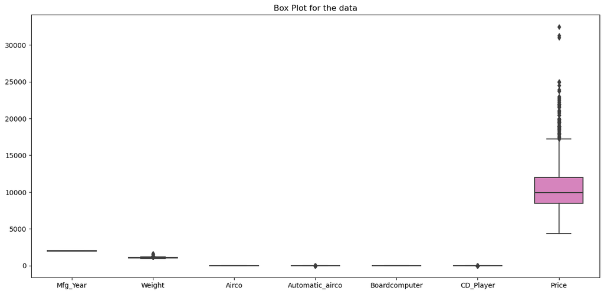

```python
plt.figure(figsize=(15,7))
plt.title("Box Plot for the data")
sns.boxplot(data=data_analysis,width=0.6)
```

```python
##Treatment of outliers to profit column
```

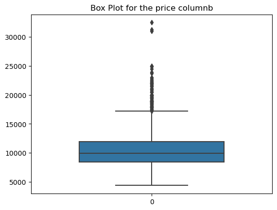

```python
###Price is having outliers
###From the above chart profit has outliers, so we can see the chart for it
plt.title("Box Plot for the price columnb")
sns.boxplot(data=data_analysis['Price'],width=0.6)
```

```python
### Describing data['Profit'] before treating
data_analysis['Price'].describe()
```

```
count     1436.000000
mean     10730.824513
std       3626.964585
min       4350.000000
25%       8450.000000
50%       9900.000000
75%      11950.000000
max      32500.000000
Name: Price, dtype: float64
```

```python
outliers = []

def detect_outliers_iqr(data):
    data = sorted(data)
    q1 = np.percentile(data, 25)
    q3 = np.percentile(data, 75)
    # print(q1, q3)
    IQR = q3-q1
    lwr_bound = q1-(1.5*IQR)
    upr_bound = q3+(1.5*IQR)
    # print(lwr_bound, upr_bound)
    for i in range(0,len(data)):
        if (data[i]<lwr_bound ):
            data[i] = lwr_bound
        elif (data[i]>upr_bound):
            data[i] = upr_bound


    return data # Driver code
```

```python
price_outliers = detect_outliers_iqr(data_analysis['Price'])
data_analysis['price_outliers'] = price_outliers
```

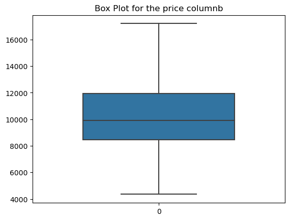

```python
###Price is having outliers
###From the above chart profit has outliers, so we can see the chart for it
plt.title("Box Plot for the price columnb")
sns.boxplot(data=price_outliers,width=0.6)
```

```python
data_analysis['price_outliers'].describe()

####Since the outliers are removed we can change the price column with this values
```

```
count     1436.000000
mean     10500.633008
std       2981.813672
min       4350.000000
25%       8450.000000
50%       9900.000000
75%      11950.000000
max      17200.000000
Name: price_outliers, dtype: float64
```

```python
data_analysis['Price'] = data_analysis['price_outliers']
data_analysis.drop(columns='price_outliers',axis=1,inplace=True)
```

```python
### Describing data['Profit'] after treating
data_analysis['Price'].describe()
```

```
count     1436.000000
mean     10500.633008
std       2981.813672
min       4350.000000
25%       8450.000000
50%       9900.000000
75%      11950.000000
max      17200.000000
Name: Price, dtype: float64
```

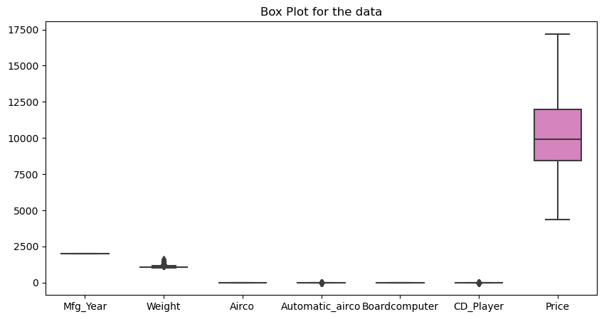

```python
plt.figure(figsize=(10,5))
plt.title("Box Plot for the data")
sns.boxplot(data=data_analysis,width=0.6)
```

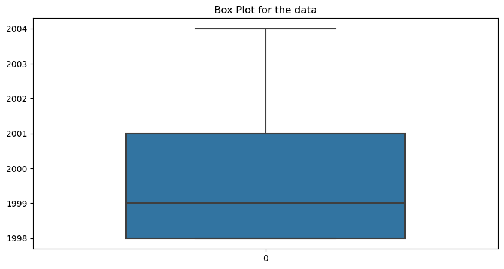

```python
plt.figure(figsize=(10,5))
plt.title("Box Plot for the data")
sns.boxplot(data=data_analysis['Mfg_Year'],width=0.6)
```

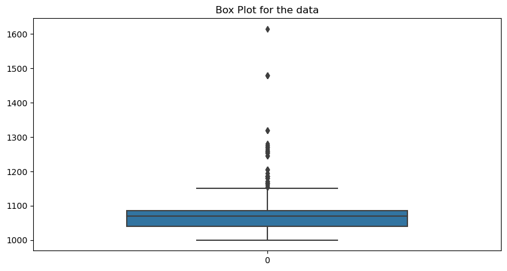

```python
plt.figure(figsize=(10,5))
plt.title("Box Plot for the data")
sns.boxplot(data=data_analysis['Weight'],width=0.6)
```

```python
data_analysis['Weight'] = detect_outliers_iqr(data_analysis['Weight'])
```

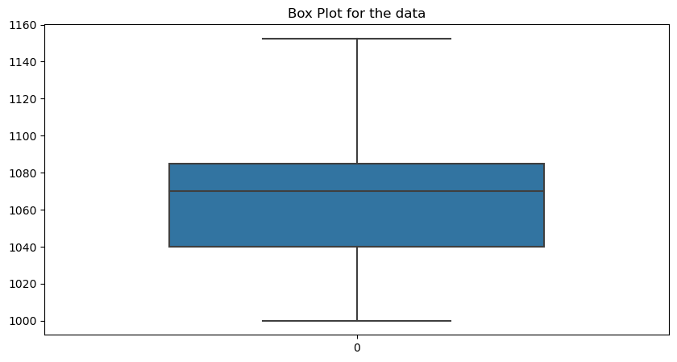

```python
plt.figure(figsize=(10,5))
plt.title("Box Plot for the data")
sns.boxplot(data=data_analysis['Weight'],width=0.6)
```

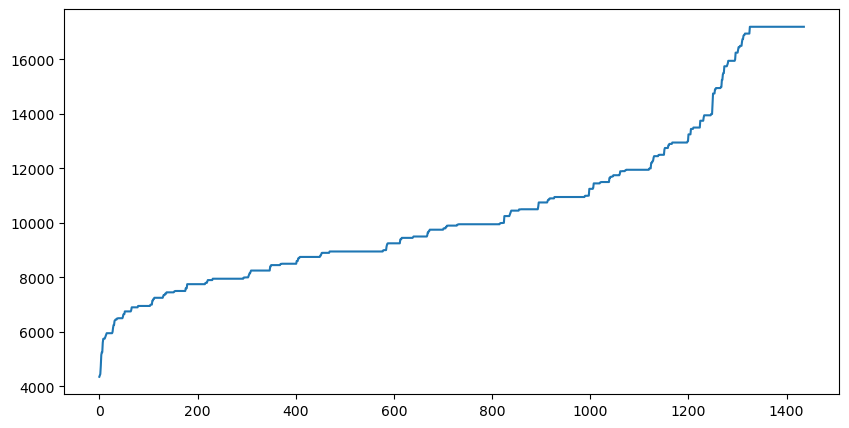

```python
data_analysis['Price'].plot(kind='line',figsize = (10,5))
```

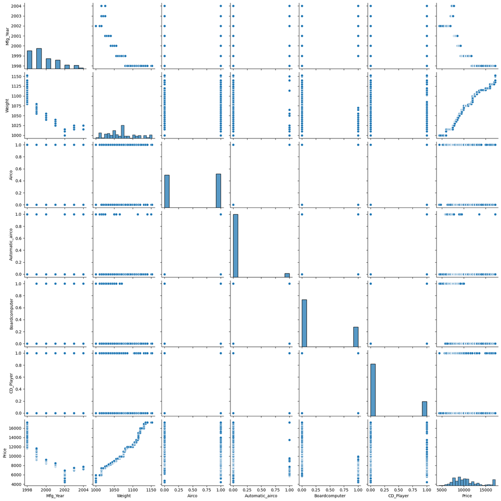

```python
sns.pairplot(data=data_analysis)
```

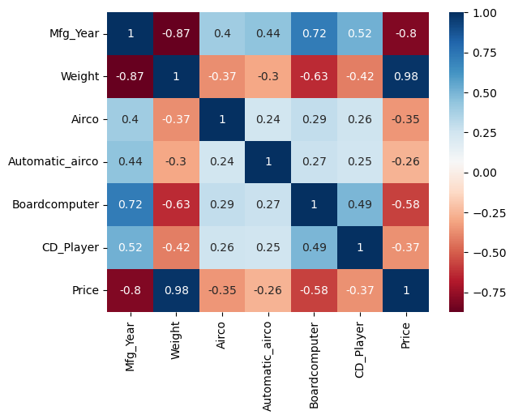

```python
###Checking the correclation between two columns
sns.heatmap(data=data_analysis.corr(),annot=True,cmap="RdBu")
```

# Modelling

```python
###Model 1
def linear_pred_model(x,y):
    model1 =LinearRegression()
    train_model1 = model1.fit(x,y)
    pred = train_model1.predict(x)
    print("The accuracy is..",round(r2_score(pred,y)*100,2),"%")
    print("The Error is..",m.sqrt(mean_squared_error(pred,y)))
```

```python
linear_pred_model(x,y)
```

```
The accuracy is.. 82.81 %
The Error is.. 1388.7276740603609
```

```python
###Model 2
##### Instead of running the same code many times we can create a model

def linear_pred_model1(x,y,test_data_size):
    ### Spliting of test and train data
    x_train_data,x_test_data,y_train_data,y_test_data = train_test_split(x,y,test_size=test_data_size,random_state=1234)
    #print(x_train_data.shape)
    #print(y_train_data.shape)
    #print(x_test_data.shape)
    #print(y_test_data.shape)
    ### Model creation
    model = LinearRegression()
    train_model = model.fit(x_train_data,y_train_data)
    print("Training of Model is Done...")

    ### Predicting of accuracy
    print("The accuracy by r2 score is..",round(r2_score(y_test_data,train_model.predict(x_test_data))*100,2),"% for the model with test size",test_data_size)
```

```python
#### 80% train data and 20% test data

linear_pred_model1(x,y,0.2)
```

```
Training of Model is Done...
The accuracy by r2 score is.. 86.8 % for the model with test size 0.2
```

```python
#### 70% train data and 30% test data

linear_pred_model1(x,y,0.3)
```

```
Training of Model is Done...
The accuracy by r2 score is.. 85.91 % for the model with test size 0.3
```

```python
#### 60% train data and 40% test data
linear_pred_model1(x,y,0.4)
```

```
Training of Model is Done...
The accuracy by r2 score is.. 83.79 % for the model with test size 0.4
```

Sooo model with 20% test data and 80 % train data has the highest percentage of accuracy

```python
###Model 3
##### Instead of running the same code many times we can create a model

def linear_pred_price(x,y,test_data_size):
    ### Spliting of test and train data
    x_train_data,x_test_data,y_train_data,y_test_data = train_test_split(x,y,test_size=test_data_size,random_state=1234)
    ### Model creation
    model = LinearRegression()
    train_model = model.fit(x_train_data,y_train_data)
    print("Training of Model is Done...")

    return pd.DataFrame({'Price':y_test_data,'Pred_Price':train_model.predict(x_test_data)})
```

```python
linear_pred_price(x,y,0.2)
```

```
Training of Model is Done...
```

|  | Price | Pred_Price |
| --- | --- | --- |
| 630 | 7500 | 9858.075470 |
| 454 | 11950 | 11047.841541 |
| 148 | 19450 | 20196.955493 |
| 110 | 31000 | 25067.410282 |
| 1054 | 8750 | 8220.745928 |
| ... | ... | ... |
| 99 | 17450 | 16801.777050 |
| 854 | 8950 | 9020.816162 |
| 202 | 10500 | 12918.430391 |
| 648 | 8000 | 9104.542093 |
| 254 | 9940 | 12823.689127 |

288 rows × 2 columns